# 03-01. 지도학습 (KNN, 선형회귀, 정규화 회귀, 로지스틱, SVM, SGD)

### 일반화, 과대적합, 과소적합

#### 일반화 : 모형이 새로운 데이터에 대해 좋은 성능으로 예측

#### 과대적합 : 훈련 데이터에 좋은 성능 / 평가 데이터에 나쁜 성능 (복잡한 모형)

#### 과소적합 : 훈련 데이터, 평가 데이터 모두에 나쁜 성능

### 데이터 로드 및 전처리

```python
import pandas as pd
import numpy as np
import matplotlib.pyplot as plt
import sklearn
import mglearn
import warnings
warnings.filterwarnings(action = 'ignore')
```

```python
heart = pd.read_csv("C:/Soongsil/4-2학기/데이터 마이닝/데마 조별/heart.csv")
```

```python
heart.shape
target = heart.HeartDisease
feature = heart.drop("HeartDisease", axis = 1)
```

- **수치형 변수들은 Standard Scale / 범주형 변수들은 원-핫 인코딩**

```python
from sklearn.compose import make_column_transformer
from sklearn.preprocessing import OneHotEncoder
from sklearn.preprocessing import StandardScaler
```

```python
ct = make_column_transformer(
    (StandardScaler(), ['Age', 'RestingBP', 'Cholesterol', 'FastingBS', 'MaxHR', 'Oldpeak']),
    (OneHotEncoder(sparse = False), ['Sex', 'ChestPainType', 'RestingECG', 'ExerciseAngina', 'ST_Slope'])
)
```

### 데이터 분할

### `sklearn.model_selection.train_test_split(설명변수, 반응변수, train_size, random_state, stratify)`

```python
from sklearn.model_selection import train_test_split
```

```python
x_train, x_test, y_train, y_test = train_test_split(feature, target,
                                                    stratify = heart.Sex,
                                                    train_size=0.7,
                                                    random_state=0)
```

```python
x_train.shape, x_test.shape, y_train.shape, y_test.shape
```

```
((642, 11), (276, 11), (642,), (276,))
```

```python
ct.fit(x_train)
ct.get_feature_names_out()
x_train_trans = ct.fit_transform(x_train)
x_test_trans = ct.fit_transform(x_test)
```

```python
x_train_trans.shape, x_test_trans.shape, y_train.shape, y_test.shape
```

```
((642, 20), (276, 20), (642,), (276,))
```

## sklearn 모델 생성

1. **각 모델별 라이브러리 import**
2. **각 모델별 제너레이터 생성 (모형 생성)**
3. **`모델.fit(x, y)`으로 데이터 적합**
4. **`모델.predict(x)`으로 예측값 생성**
5. **`모델.score(x, y)`로 모델 평가**

## KNN

- 매개변수 : 데이터 포인트 사이의 거리 계산법, 이웃의 수
- 훈련 데이터의 차원이 크면, 예측이 느려짐 (전처리 과정이 중요)

### KNN 분류

### `sklearn.neighbors.KNeighborsClassifier(n_neighbors)`

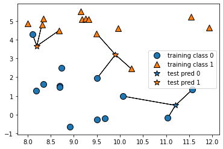

```python
mglearn.plots.plot_knn_classification(3)
```

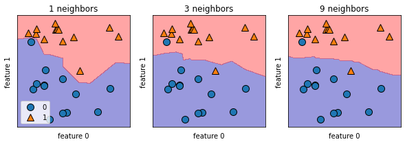

```python
fig, axes = plt.subplots(1, 3, figsize = (10, 3))

x, y = mglearn.datasets.make_forge()
xtr, xts, ytr, yts = train_test_split(x, y, random_state = 0)

for n, ax in zip([1, 3, 9], axes) :
    clf = KNeighborsClassifier(n_neighbors=n).fit(x, y)
    mglearn.plots.plot_2d_separator(clf, x, fill = True,
                                    eps = 0.5, ax = ax, alpha = .4)
    mglearn.discrete_scatter(x[:, 0], x[:, 1], y, ax = ax)
    ax.set_title("{} neighbors".format(n))
    ax.set_xlabel("feature 0")
    ax.set_ylabel("feature 1")

axes[0].legend(loc = 3)
plt.show()
```

```python
from sklearn.neighbors import KNeighborsClassifier
```

```python
x, y = mglearn.datasets.make_forge()
xtr, xts, ytr, yts = train_test_split(x, y, random_state = 0)
clf = KNeighborsClassifier(n_neighbors=3)
```

```python
clf.fit(xtr, ytr)
clf.score(xtr, ytr), clf.score(xts, yts)
```

```
(0.9473684210526315, 0.8571428571428571)
```

```python
knn_classify = KNeighborsClassifier(n_neighbors = 3)
knn_classify.fit(x_train_trans, y_train)
knn_classify.score(x_train_trans, y_train), knn_classify.score(x_test_trans, y_test)
```

```
(0.9049844236760125, 0.8478260869565217)
```

- **n_neighbors별 훈련/평가 데이터 정확도**

```python
train_acc = []
test_acc = []
neighbors_setting = range(1, 11)
```

```python
for n in neighbors_setting :
    clf = KNeighborsClassifier(n_neighbors = n)
    clf.fit(x_train_trans, y_train)
    train_acc.append(clf.score(x_train_trans, y_train))
    test_acc.append(clf.score(x_test_trans, y_test))
```

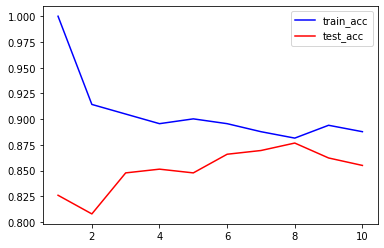

```python
plt.plot(neighbors_setting, train_acc, 'b', label = 'train_acc')
plt.plot(neighbors_setting, test_acc, 'r', label = 'test_acc')
plt.legend()
plt.show()
```

### KNN 회귀

### `sklearn.neighbors.KNeighborsRegressor(n_neighbors)`

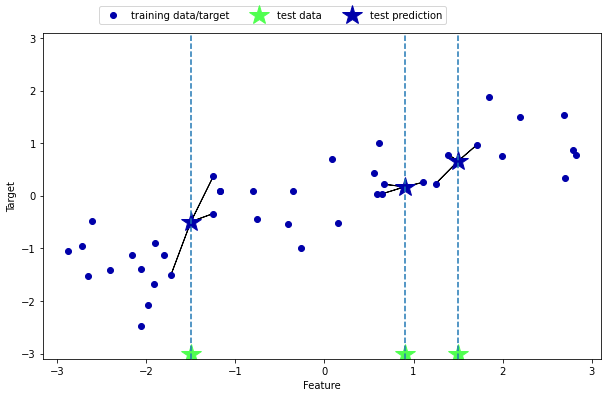

```python
mglearn.plots.plot_knn_regression(3)
```

```python
from sklearn.neighbors import KNeighborsRegressor
```

```python
bike = mglearn.datasets.load_citibike()
```

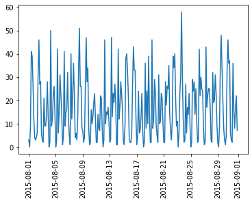

```python
plt.plot(bike.index, bike.values)
plt.xticks(rotation = 90)
plt.show()
```

```python
y = bike.values
x_hour = bike.index.hour.values.reshape(-1, 1)
x_dayofweek = bike.index.dayofweek.values.reshape(-1, 1)
x = np.hstack([x_hour, x_dayofweek])
```

```python
enc = OneHotEncoder(sparse=False)
x_enc = enc.fit_transform(x)
```

```python
n_train = int(bike.shape[0] * 0.75)
n_train
```

```
186
```

```python
y_train, y_test = y[:n_train].reshape(-1, 1), y[n_train:].reshape(-1, 1)
x_train, x_test = x_enc[:n_train, :], x_enc[n_train:, :]
```

```python
y_train.shape, y_test.shape, x_train.shape, x_test.shape
```

```
((186, 1), (62, 1), (186, 15), (62, 15))
```

```python
knn_reg = KNeighborsRegressor(n_neighbors=3)
knn_reg.fit(x_train, y_train)
knn_reg.score(x_train, y_train), knn_reg.score(x_test, y_test)
```

```
(0.8821767365074451, 0.8319575353101378)
```

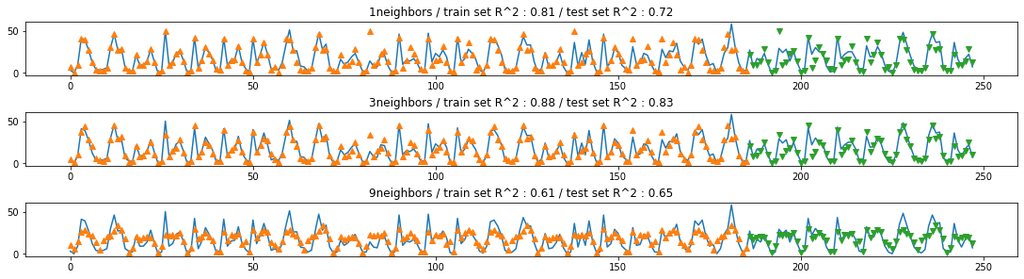

```python
fig, axes = plt.subplots(3, 1, figsize = (15, 4), constrained_layout=True)

for n, ax in zip([1, 3, 9], axes):
    reg = KNeighborsRegressor(n)
    reg.fit(x_train, y_train)
    pred_train, pred_test = reg.predict(x_train), reg.predict(x_test)
    score_train, score_test = reg.score(x_train, y_train), reg.score(x_test, y_test)

    ax.plot(range(len(y)), y, label = 'actual')
    ax.plot(range(n_train), pred_train, '^', label = 'pred_train')
    ax.plot(range(n_train, n_train + len(y_test)), pred_test, 'v', label = 'pred_test')
    ax.set_title(
        "{}neighbors / train set R^2 : {:.2f} / test set R^2 : {:.2f}".format(
            n, score_train, score_test)
    )
```

## 선형 회귀

- 예측값과 실제값 에있는 반응변수 사이의 평균제곱오차(MSE)를 최소화 하는 회귀 계수를 탐색 (OLSE)

- $x$ : 입력 데이터
- $w$ : 모델이 학습할 파라미터
- $w_0$ : 편향
- $w_1 ~ w_p$ : 가중치

#### $MSE = {1 \over n} {\sum^n_{1}}(y_i - \hat{y}_i)^2$

### `sklearn.linear_model.LinearRegression()`

```python
from sklearn.linear_model import LinearRegression
```

```python
lr = LinearRegression()
lr.fit(x_train, y_train)
lr.score(x_train, y_train), lr.score(x_test, y_test)
```

```
(0.5390846851557511, 0.6154271733474396)
```

### `lr.coef_` : 회귀 계수

### `lr.intercept_` : 절편

```python
x_train.shape, lr.coef_.shape
```

```
((186, 15), (1, 15))
```

```python
lr.intercept_, lr.coef_
```

```
(array([7.79508808e+13]),
 array([[-2.80774292e+14, -2.80774292e+14, -2.80774292e+14,
         -2.80774292e+14, -2.80774292e+14, -2.80774292e+14,
         -2.80774292e+14, -2.80774292e+14,  2.02823411e+14,
          2.02823411e+14,  2.02823411e+14,  2.02823411e+14,
          2.02823411e+14,  2.02823411e+14,  2.02823411e+14]]))
```

```python
pred_train, pred_test = lr.predict(x_train), lr.predict(x_test)
```

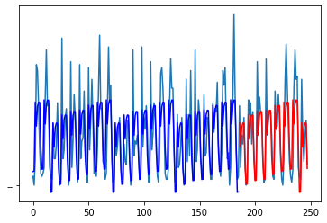

```python
plt.plot(range(len(y)), y, label = 'actual')
plt.plot(range(n_train), pred_train,
         'b', '--', label = 'pred_train')
plt.plot(range(n_train, n_train + len(y_test)), pred_test,
         'r', '--', label = 'pred_test')
plt.show()
```

### 릿지회귀

### `sklearn.linear_model.Ridge(alpha, solver, positive, max_iter, ...)`

- `alpha` : $\alpha$, L2규제의 정도, 크게하면 페널티의 효과가 커짐 (계수 절댓값 감소) (0 = default)
- `solver` : 적용 알고리즘 ('auto' : default). (훈련 데이터가 희소 행렬이면 'sparce_cg' / 'cholesky')
- `positive` : True이면 계수값을 강제로 양수로 => 'lbfgs'알고리즘 ('sag' : 확률적 평균 경사 하강법 / 'saga' : 'sag'의 개선)
- `max_iter` : 반복횟수 ('sparce_cg'일 때 샘플 개수의 10개 / 'sag', 'saga'일 때 1000 / 'ibfgs'일 떄 150000)
- 회귀계수의 절댓값을 가능한 작게 => 회귀계수의 모든 원소가 0에 가깝게 => 출력에 주는 영향을 최소한으로 (규제)
- 규제 : 과대적합이 되지 않도록 모형을 강제로 제한 (L2규제)

#### $L2규제(RidgeMSE) => MSE + \alpha \sum^m_{j=1} w^2_j = \frac{1}{N} \sum_{i=1}^{N}(y_i - \hat{y}_i)^2 + \alpha \sum_{j=1}^{m} w_j^2$

```python
Ridge(p)
```

```python
from sklearn.linear_model import Ridge
```

```python
ridge10 = Ridge(alpha=10).fit(x_train, y_train)
ridge10.score(x_train, y_train), ridge10.score(x_test, y_test)
```

```
(0.49333901462008956, 0.5369516424548919)
```

```python
ridge01 = Ridge(alpha=.1).fit(x_train, y_train)
ridge01.score(x_train, y_train), ridge01.score(x_test, y_test)
```

```
(0.5396654395675035, 0.61007095317458)
```

```python
pred10 = ridge10.predict(x_enc)
pred01 = ridge01.predict(x_enc)
```

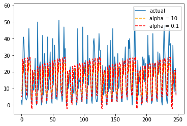

```python
plt.plot(range(len(y)), y, label = 'actual')
plt.plot(range(len(y)), pred10,
         color = 'orange', linestyle = '--', label = 'alpha = 10')
plt.plot(range(len(y)), pred01,
         color = 'r', linestyle = '--', label = 'alpha = 0.1')
plt.legend()
plt.show()
```

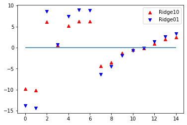

```python
plt.scatter(range(lr.coef_.shape[1]), ridge10.coef_,
            marker = '^', color = 'r', label = "Ridge10")
plt.scatter(range(lr.coef_.shape[1]), ridge01.coef_,
            marker = 'v', color = 'b', label = "Ridge01")
plt.hlines(0, np.min(range(lr.coef_.shape[1])), np.max(range(lr.coef_.shape[1])))
plt.legend()
plt.show()
```

### 라쏘

### `sklearn.linear_model.Lasso(alpha, positive, max_iter, ...)`

- `alpha` : $\alpha$, L1규제의 정도, 크게하면 페널티의 효과가 커짐 (계수 절댓값 감소) (0 = default)
- `positive` : True이면 계수값을 강제로 양수로 => 'lbfgs'알고리즘 ('sag' : 확률적 평균 경사 하강법 / 'saga' : 'sag'의 개선)
- `max_iter` : 반복횟수 ('sparce_cg'일 때 샘플 개수의 10개 / 'sag', 'saga'일 때 1000 / 'ibfgs'일 떄 150000)
- 가능한 많은 회귀계수의 절댓값을 0으로
- 규제 : 과대적합이 되지 않도록 모형을 강제로 제한 (L1규제)

#### $L1규제 (LassoMSE) => MSE + \alpha \sum^m_{j=1} |w_j| = \frac{1}{N} \sum_{i=1}^{N} (y_i - \hat{y}_i)^2 + \alpha \sum_{j=1}^{m} |w_j|$

```python
from sklearn.linear_model import Lasso
```

```python
Lasso001 = Lasso(0.01, max_iter = 50000).fit(x_train, y_train)
Lasso001.score(x_train, y_train), Lasso001.score(x_test, y_test)
```

```
(0.539618214037898, 0.6108162316154027)
```

```python
Lasso00001 = Lasso(0.0001, max_iter = 50000).fit(x_train, y_train)
Lasso00001.score(x_train, y_train), Lasso00001.score(x_test, y_test)
```

```
(0.5396746678106374, 0.6104808779217142)
```

```python
pred001 = Lasso001.predict(x_enc)
pred00001 = Lasso00001.predict(x_enc)
```

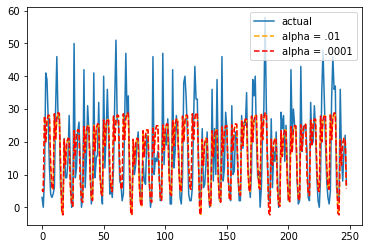

```python
plt.plot(range(len(y)), y, label = 'actual')
plt.plot(range(len(y)), pred001,
         color = 'orange', linestyle = '--', label = 'alpha = .01')
plt.plot(range(len(y)), pred00001,
         color = 'r', linestyle = '--', label = 'alpha = .0001')
plt.legend()
plt.show()
```

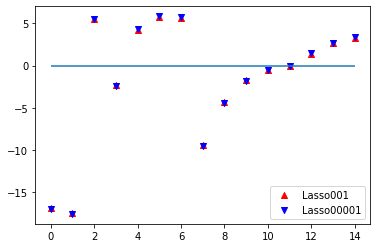

```python
plt.scatter(range(lr.coef_.shape[1]), Lasso001.coef_,
            marker = '^', color = 'r', label = "Lasso001")
plt.scatter(range(lr.coef_.shape[1]), Lasso00001.coef_,
            marker = 'v', color = 'b', label = "Lasso00001")
plt.hlines(0, np.min(range(lr.coef_.shape[1])), np.max(range(lr.coef_.shape[1])))
plt.legend()
plt.show()
```

### Elastic Net

### `sklearn.linear_model.ElasticNet(alpha, l1_ratio)`

- `alpha`: 규제 계수
- `l1_ratio` : l1_ratio = 0 (L2 규제만 사용) / l1_ratio = 1 (L1 규제만 사용) / 0 < l1_ratio < 1 (L1 and L2 규제의 혼합사용)

[figure not shown]

- 가중치의 절대값의 합(L1)과 제곱합(L2)을 동시에 제약 조건으로 가지는 모형

\begin{equation} ElasticMSE = \frac{1}{N} \sum_{i=1}^{N} (y_i - \hat{y}_i) + \alpha \rho \sum_{i=1}^{p} |w_i| + \alpha (1 - \rho) \sum_{i=1}^{p} w_i^2 \end{equation}

- α : 규제의 강도를 조절하는 매개변수
- ρ : 라쏘 규제와 릿지 규제 사이의 가중치를 조절하는 매개변수

### Quantile Regressor

### `sklearn.linear_model.QuantileRegressor(quantile, alpha)`

- 하나의 예측값이 아닌, 예측의 백분위 간격 계산
- `quantile` : 예측하려는 백분위수를 0 ~ 1 사이로 지정 (0.5 : default)
- `alpha` : 규제강도

```python
from sklearn.linear_model import QuantileRegressor
```

- **훈련 데이터에서 학습한 90%, 50%, 10% 백분위 범위를 출력**

```python
pred_up = QuantileRegressor(quantile = 0.9, alpha=0.01).fit(x_train, y_train) \
    .predict(x_test)
```

```python
pred_med = QuantileRegressor(quantile = 0.5, alpha = 0.01).fit(x_train, y_train) \
    .predict(x_test)
pred_low = QuantileRegressor(quantile = 0.1, alpha = 0.01).fit(x_train, y_train) \
    .predict(x_test)
```

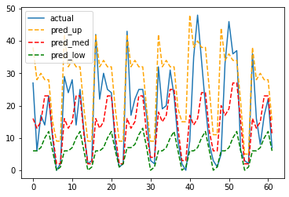

```python
plt.plot(range(len(y_test)), y_test, label = 'actual')
plt.plot(range(len(y_test)), pred_up,
         color = 'orange', linestyle = '--', label = 'pred_up')
plt.plot(range(len(y_test)), pred_med,
         color = 'r', linestyle = '--', label = 'pred_med')
plt.plot(range(len(y_test)), pred_low,
         color = 'g', linestyle = '--', label = 'pred_low')
plt.legend()
plt.show()
```

## 이진 분류 회귀

- 분류용 선형 모형에서는 **결정 경계**가 입력의 선형 함수 => 이진 선형 분류기는 초평면을 사용하여 두 개의 클래스를 구분

```python
from sklearn.linear_model import LogisticRegression
from sklearn.svm import LinearSVC
```

```python
x, y = mglearn.datasets.make_forge()
```

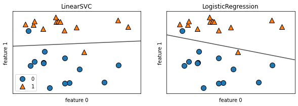

```python
fig, axes = plt.subplots(1, 2, figsize = (10, 3))

for model, ax in zip([LinearSVC(max_iter = 5000), LogisticRegression()], axes) :
    clf = model.fit(x, y)
    mglearn.plots.plot_2d_separator(clf, x, fill = False,
                                    eps = 0.5, ax = ax, alpha = .7)
    mglearn.discrete_scatter(x[:, 0], x[:, 1], y, ax = ax)
    ax.set_title(clf.__class__.__name__)
    ax.set_xlabel("feature 0")
    ax.set_ylabel("feature 1")
axes[0].legend()
plt.show()
```

### 로지스틱 회귀

\begin{equation} \sigma(x) = \frac{1}{1 + e^{-x}} \\ \hat{y} = \sigma(w_0 + w_1 x_1 + ... + w_p x_p) \end{equation}

- σ: 시그모이드 함수
- 로지스틱 회귀 모델은 선형 회귀 모델에 시그모이드 함수를 적용
- 로지스틱 회귀의 학습 목표는 다음과 같은 목적 함수를 최소화 하는 파라미터 w를 찾는 것

\begin{equation} BinaryCrossEntropy = -\frac{1}{N}\sum_{i=1}^{N}y_i\log(\hat{y}_i) + (1-y_i)\log(1-\hat{y}_i) \end{equation}

### `sklearn.linear_model.LogisticRegression(C, solver, penalty, max_iter, multi_class, ...)`

- `C` : 규제의 강도 결정 (C의 값이 클수록 규제가 감소, default = 1)
- `solver` : 사용 알고리즘
- `penalty` : 로지스틱 회귀에 적용할 규제 ("l1", "l2", "elasticnet", "none")
- `max_iter` : (default = 100)
- `multi_class` : 'auto'로 설정 시, 이진분류이거나 `solver`가 'liblinear'일 경우 'ovr'로 선택하고, 그 외에는 'multinomial'로 선택
- `solver`가 'liblinear'이고, `penalty`가 'l1'이면 L1규제
- 기본적으로 L2규제 사용
- `solver`가 'saga'면, 모든 `penalty`적용 가능
- `solver`가 'liblinear'로 지정하면, `penalty`를 'l1', 'l2' 지정 가능
- `solver`가 'newton-cg', 'lbfgs', 'sag'라면, `penalty`는 'l2'와 'none'만 지정 가능

```python
logreg1 = LogisticRegression(max_iter = 5000).fit(x_train_trans, y_train)
logreg1.score(x_train_trans, y_train), logreg1.score(x_test_trans, y_test)
```

```
(0.8769470404984424, 0.8333333333333334)
```

- **C값 증가 => 규제가 약화 => 훈련 데이터에 적합정도 증가**

```python
logreg100 = LogisticRegression(C = 100, max_iter=5000).fit(x_train_trans, y_train)
logreg100.score(x_train_trans, y_train), logreg100.score(x_test_trans, y_test)
```

```
(0.8785046728971962, 0.8369565217391305)
```

- **C값 감소 => 규제가 강화 => 훈련 데이터에서 적합정도 감소**

```python
logreg001 = LogisticRegression(C = .01, max_iter=5000).fit(x_train_trans, y_train)
logreg001.score(x_train_trans, y_train), logreg001.score(x_test_trans, y_test)
```

```
(0.8582554517133957, 0.8442028985507246)
```

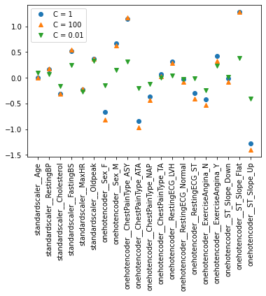

```python
plt.plot(logreg1.coef_.T, 'o', label = "C = 1")
plt.plot(logreg100.coef_.T, '^', label = "C = 100")
plt.plot(logreg001.coef_.T, 'v', label = "C = 0.01")
plt.legend()
plt.xticks(range(x_train_trans.shape[1]), ct.get_feature_names_out(), rotation = 90)
plt.show()
```

```
C = 0.001 train score : 0.463
C = 0.001 test score : 0.409
C = 1.000 train score : 0.877
C = 1.000 test score : 0.833
C = 100.000 train score : 0.879
C = 100.000 test score : 0.837
```

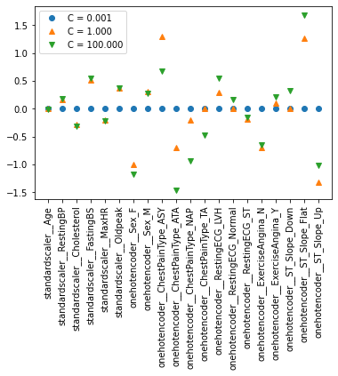

```python
for C, marker in zip([0.001, 1, 100], ['o', '^', 'v']) :
    lr_l1 = LogisticRegression(solver='liblinear', C=C,
                               penalty = 'l1', max_iter=1000)
    lr_l1.fit(x_train_trans, y_train)
    print("C = {:.3f} train score : {:.3f}".format(C, lr_l1.score(x_train_trans, y_train)))
    print("C = {:.3f} test score : {:.3f}".format(C, lr_l1.score(x_test_trans, y_test)))
    plt.plot(lr_l1.coef_.T, marker, label = "C = {:.3f}".format(C))

plt.xticks(range(x_train_trans.shape[1]), ct.get_feature_names_out(), rotation = 90)
plt.legend()
plt.show()
```

### 서포트 벡터 머신 (SVM)

### `sklearn.svm.LinearSVC(C, loss, penalty, max_iter, ...)`

- `C` : 규제의 강도 결정 (C의 값이 클수록 규제가 감소, default = 1)
- `loss` : 손실함수 (default = "squared_hinge" (제곱 힌지 손실))
- `penalty` : 제약의 종류 ("l1", "l2")
- `max_iter` : (default = 1000) #
- `loss`가 "squared_hinge"일 때, `penalty`는 'l1'과 'l2' 지정 가능
- `loss`가 "hinge"일 때, `penalty`는 'l2'만 사용 가능

## 다중 클래스 분류용 선형 모델

- 선형 분류 모형은 이진 분류만을 지원 => 다중 클래스 지원 X => 일대다 방식으로 분류
- 일대다 방식은 각 클래스를 다른 모든 클래스와 구분하도록 이진 분류 모형을 학습 => 클래스의 수 만큼 이진 분류 모형이 생성 => 예측시, 만들어진 모든 이진 분류기가 작동하여 가장 높은 점수를 내는 분류기의 클래스를 예측값으로 선택
- 클래스별 이진 분류기를 만들면, 각 클래스가 계수와 절편을 하나씩 갖게됨
- **다중 클래스 로지스틱 회귀역시, 클래스마다 하나의 계수와 절편 생성** # $Pr(Y_i = C) = {{e^{W_e X_i}} \over {\sum^K_{k=1} e^{W_k X_i}}}$ : i번재 데이터 포인트$X_i$의 출력 $Y_i$가 클래스 c일 확률은 K개의 클래스에 대한 각각의 계수 $W$를 데이터 포인트에 곱하여 지수함수를 적용한 합으로 클래스 c에 대한 값을 나누어 계산

  소프트맥스 함수의 표현에서 수식의 간소함을 위해 절편은 계수 W에 포함되어 있는 것으로 나타남. 따라서 다중 클래스 로지스틱 회귀에서도, 클래스마다 계수와 절편이 존재

```python
from sklearn.datasets import make_blobs
```

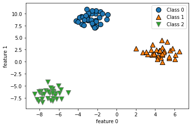

```python
x, y = make_blobs(random_state=42)
mglearn.discrete_scatter(x[:, 0], x[:, 1], y)
plt.xlabel("feature 0")
plt.ylabel("feature 1")
plt.legend(["Class 0", "Class 1", "Class 2"])
plt.show()
```

```python
from sklearn.svm import LinearSVC
```

```python
svc = LinearSVC().fit(x, y)
```

```python
svc.intercept_, svc.coef_
```

```
(array([-1.07745353,  0.13140551, -0.08605013]),
 array([[-0.17492461,  0.23141097],
        [ 0.47621425, -0.0693755 ],
        [-0.18914205, -0.20400595]]))
```

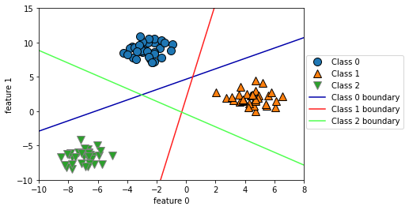

```python
mglearn.discrete_scatter(x[:, 0], x[:, 1], y)

line = np.linspace(-15, 15)
for coef, intercept, color in zip(svc.coef_, svc.intercept_, mglearn.cm3.colors) :
    plt.plot(line, -(line * coef[0] + intercept) / coef[1], c = color)

plt.ylim(-10, 15)
plt.xlim(-10, 8)
plt.xlabel("feature 0")
plt.ylabel('feature 1')
plt.legend(["Class 0", "Class 1", "Class 2",
            "Class 0 boundary", "Class 1 boundary", "Class 2 boundary"],
            loc = (1.01, 0.3))
plt.show()
```

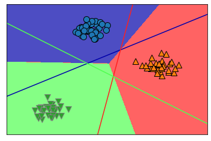

```python
mglearn.plots.plot_2d_classification(svc, x, fill = True, alpha = .7)
mglearn.discrete_scatter(x[:, 0], x[:, 1], y)
line = np.linspace(-15, 15)

for coef, intercept, color in zip(svc.coef_, svc.intercept_, mglearn.cm3.colors):
    plt.plot(line, -(line * coef[0] + intercept) / coef[1], c = color)
plt.show()
```

#### 선형 모형의 주요 매개변수 `alpha`, 분류에서는 `C`

- alpha 값이 클수록, C 값이 작을수록 모형의 규제가 증가 => 모형이 단순해짐
- 보통 C와 alpha는 로그 스케일로 최적치를 선정
- 중요한 변수가 많지 않다고 생각하면 L1규제 / 그렇지 않으면 L2규제
- 선형모형은 학습 속도가 빠르고, 예측도 빠름

#### 수십만에서 수백만 개의 샘플로 이루어진 대용량 데이터셋이라면, 기본 설정보다 빨리 처리하도록 `LogisticRegression`과 `Ridge`에 `solver = 'sag'`혹은 `SGDClassifier`, `SGDRegressor`

## SGD 확률적 경사 하강법

- 대용량 데이터에 사용 용이

### `sklearn.linear_model.SGDClassifier(loss, penalty, alpha, learning_rate, max_iter, early_stopping, n_iter_no_change, tol, ...)`

- `loss` : 손실함수 (hinge" : 서포트 벡터 머신 / "log" : 로지스틱)
- `penalty` : 규제 ("l1", "l2", "elasticnet") (default = "l2")
- `alpha` : 규제강도 조정 (default = 0.0001, 값이 클수록 규제강도가 높아짐)
- `learning_rate` : 학습률 ("optimal" : default, 반복횟수에 따라 비례적으로 감소 / "constant" :
- `eta0`으로 지정한 값을 사용 / "invscaling" : `eta0`에서 시작해서 지수적으로 감소 / "adaptive" : `eta0`에 지정한 값에서 시작해서 조기 종료 조건이 될 대마다 5배씩 줄이며 학습률이 1e-6보다 작아지면, 알고리즘을 종료)
- `max_iter` : 반복 횟수 (default = 1000)
- `early_stopping` : 조기종료 옵션 (default = False)
- `tol` : 조기종료 기준 값
- `n_iter_no_change` : 지정한 반복 동안 훈련 데이터 점수가 `tol`만큼 향상되지 않으면, 훈련 종료
- `n_jobs` : 일대 다 다중 분류를 병렬화하기 위해, 사용할 CPU 코어 개수 지정

\begin{equation} \frac{\partial L}{\partial w} = \underset{h \rightarrow 0}{lim} \frac{L(w+h) - L(w)}{h} \\ w^{'} = w - \alpha \frac{\partial L}{\partial w} \end{equation}

```python
from sklearn.linear_model import SGDClassifier
```

```python
sgd_c = SGDClassifier(alpha = 0.01, learning_rate="adaptive",
                      eta0 = 0.1, random_state=42, n_jobs=-1)
```

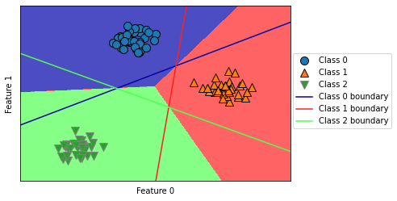

```python
sgd_c.fit(x, y)
mglearn.plots.plot_2d_classification(sgd_c, x, fill = True, alpha = .7)
mglearn.discrete_scatter(x[:, 0], x[:, 1], y)
line = np.linspace(-15, 15)

for coef, intercept, color in zip(sgd_c.coef_, sgd_c.intercept_, mglearn.cm3.colors):
    plt.plot(line, -(line * coef[0] + intercept) / coef[1], c = color)
plt.legend(['Class 0', 'Class 1', 'Class 2',
            'Class 0 boundary', 'Class 1 boundary', 'Class 2 boundary'],
           loc=(1.01, 0.3))
plt.xlabel("Feature 0")
plt.ylabel("Feature 1")
plt.show()
```

### `sklearn.linear_model.SGDRegressor(loss, penalty, learning_rate, eta0, ...)`

- `loss` : 손실함수 (default = "squared_loss", 릿지회귀)
- `penalty` : 규제 ("l1", "l2", "elasticnet") (default = "l2")
- `learning_rate` : 학습률 ("optimal" : default, 반복횟수에 따라 비례적으로 감소 / "constant" : `eta0`으로 지정한 값을 사용 / "invscaling" : `eta0`에서 시작해서 지수적으로 감소 / "adaptive" : `eta0`에 지정한 값에서 시작해서 조기 종료 조건이 될 대마다 5배씩 줄이며 학습률이 1e-6보다 작아지면, 알고리즘을 종료)
- `eta0` : 지정 학습률 (default = 0)
- `max_iter` : 반복 횟수 (default = 1000)
- `early_stopping` : 조기종료 옵션 (default = False)
- `tol` : 조기종료 기준 값
- `n_iter_no_change` : 지정한 반복 동안 훈련 데이터 점수가 `tol`만큼 향상되지 않으면, 훈련 종료
- `n_jobs` : 일대 다 다중 분류를 병렬화하기 위해, 사용할 CPU 코어 개수 지정

\begin{equation} \frac{\partial L}{\partial w} = \underset{h \rightarrow 0}{lim} \frac{L(w+h) - L(w)}{h} \\ w^{'} = w - \alpha \frac{\partial L}{\partial w} \end{equation}

```python
from sklearn.linear_model import SGDRegressor
```

```python
x, y = mglearn.datasets.load_extended_boston()
x_train, x_test, y_train, y_test = train_test_split(x, y, random_state = 0)
```

```python
sgd_r = SGDRegressor(learning_rate='adaptive', eta0=0.1, random_state=42)
sgd_r.fit(x_train, y_train)
print("Train Data Score : {:.2f}".format(sgd_r.score(x_train, y_train)))
print("Test Data Score : {:.2f}".format(sgd_r.score(x_test, y_test)))
```

```
Train Data Score : 0.91
Test Data Score : 0.77
```